# Dream Home/Investment

Jisha

February 27, 2018

```r
#install.packages("plyr")
#install.packages("dplyr")
#install.packages("tidyr")
#install.packages("ggplot2")
#install.packages("scales")
#install.packages("graphics")
#install.packages("caret")

library(plyr)

library(dplyr)
library(stringr)
library(tidyr)
library(ggplot2)
library(scales)
library(graphics)
library(caret)
```

# Convert to local dataframe

```r
homedf <- read.csv("C:/springboard_capstone_project/final_project/home_poject_data/train.csv", header = TRUE)
homedf <- read.csv("C:/springboard_capstone_project/final_project/home_poject_data/train.csv",stringsAsFactors = FALSE)
homedf <- as.data.frame(homedf)
homedf <- tbl_df(homedf)
glimpse(homedf)
```

```
## Observations: 1,460
## Variables: 81
## $ Id            <int> 1, 2, 3, 4, 5, 6, 7, 8, 9, 10, 11, 12, 13, 14, 1...
## $ MSSubClass    <int> 60, 20, 60, 70, 60, 50, 20, 60, 50, 190, 20, 60,...
## $ MSZoning      <chr> "RL", "RL", "RL", "RL", "RL", "RL", "RL", "RL", ...
## $ LotFrontage   <int> 65, 80, 68, 60, 84, 85, 75, NA, 51, 50, 70, 85, ...
## $ LotArea       <int> 8450, 9600, 11250, 9550, 14260, 14115, 10084, 10...
## $ Street        <chr> "Pave", "Pave", "Pave", "Pave", "Pave", "Pave", ...
## $ Alley         <chr> NA, NA, NA, NA, NA, NA, NA, NA, NA, NA, NA, NA, ...
## $ LotShape      <chr> "Reg", "Reg", "IR1", "IR1", "IR1", "IR1", "Reg",...
## $ LandContour   <chr> "Lvl", "Lvl", "Lvl", "Lvl", "Lvl", "Lvl", "Lvl",...
## $ Utilities     <chr> "AllPub", "AllPub", "AllPub", "AllPub", "AllPub"...
## $ LotConfig     <chr> "Inside", "FR2", "Inside", "Corner", "FR2", "Ins...
## $ LandSlope     <chr> "Gtl", "Gtl", "Gtl", "Gtl", "Gtl", "Gtl", "Gtl",...
## $ Neighborhood  <chr> "CollgCr", "Veenker", "CollgCr", "Crawfor", "NoR...
```

[output cut: 68 more lines]

Description of Dataset The dataset is Kaggle competitions ’Iowa House Prices: Regression Techniques ’train.csv.The dataset contains 81 variables and 1460 observations.Of the 81 variables, 23 are nominal, 23 are ordinal, 14 are discrete, and 20 are continuous. The variables included are basic characteristics that anyone wanting to buy a house would be interested in.

Cleaning data

#Finding the missing values in data

```r
any(is.na(homedf))
```

```
## [1] TRUE
```

# How many are there

```r
sum(is.na(homedf))
```

```
## [1] 6965
```

```r
# Return index of columns that have missing values
na.cols = which(colSums(is.na(homedf)) >0 )
#Break down missing values by variable
sort(colSums(sapply(homedf[na.cols], is.na)), decreasing = TRUE)
```

```
##       PoolQC  MiscFeature        Alley        Fence  FireplaceQu
##         1453         1406         1369         1179          690
##  LotFrontage   GarageType  GarageYrBlt GarageFinish   GarageQual
##          259           81           81           81           81
##   GarageCond BsmtExposure BsmtFinType2     BsmtQual     BsmtCond
##           81           38           38           37           37
## BsmtFinType1   MasVnrType   MasVnrArea   Electrical
##           37            8            8            1
```

```r
#homedf %>%
#dplyr:: select(everything(),- PoolQC)
```

Alley have NA encoded as a level to specify No Alley Access.It’s not “missing” values.There are 1369 missing values in Alley.Coding the NAs to No Alley, fixes all these missing values.

```r
homedf$Alley[is.na(homedf$Alley)]<- "No Alley"
```

690 FireplaceQu is missing. Fireplace column shows the range of fire places from 0 to 3.Assuming 690 homes doesn’t have a fireplace change the ‘NA’ to ‘No fireplace’.

```r
table(homedf$Fireplaces)
```

```
##
##   0   1   2   3
## 690 650 115   5
```

```r
homedf$FireplaceQu[is.na(homedf$FireplaceQu)]<- "No Fireplace"
```

```r
table(homedf$FireplaceQu)
```

```
##
##           Ex           Fa           Gd No Fireplace           Po
##           24           33          380          690           20
##           TA
##          313
```

1179 missing values in Fence. Changing the NA’s to “No Fence”

```r
homedf$Fence[is.na(homedf$Fence)]<- "No Fence"
```

```r
table(homedf$Fence)
```

```
##
##    GdPrv     GdWo    MnPrv     MnWw No Fence
##       59       54      157       11     1179
```

259 values are missing in LotFrontage.There is no single variable in the dataset that gives a reason why these values are missing. We make the assumption that the lot frontage for a given house is fairly similar to the other properties. # Populating the NA’s with the mean of lot frontage

```r
lf.mean <- mean(homedf$LotFrontage, na.rm=TRUE)
homedf$LotFrontage[is.na(homedf$LotFrontage)] = lf.mean
lf.mean
```

```
## [1] 70.04996
```

5 Garage variables are missing 81 values.Checking the variables ‘GarageCars’ and ‘GarageArea’ gives the idea there is no garage built with the home .So the missing values are ‘none’.

```r
# Changing NA's in garage variable to none
homedf$GarageType[is.na(homedf$GarageType)]<- "None"
homedf$GarageFinish[is.na(homedf$GarageFinish)]<- "None"
homedf$GarageQual[is.na(homedf$GarageQual)]<- "None"
homedf$GarageCond[is.na(homedf$GarageCond)]<- "None"
```

```r
# Fill in Garage year Built
homedf$GarageYrBlt[is.na(homedf$GarageYrBlt)]<- "0"
```

Missing values in BsmtExposure,BsmtFinType1,BsmtFinType2,BsmtQual,BsmtCond is related with Basement sqrft 0.The missing values shows there is no basement.

```r
# Changing the Na's in Bsmt features with "No Basement"
homedf$BsmtExposure[is.na(homedf$BsmtExposure)]<- "No Basement"
homedf$BsmtFinType2[is.na(homedf$BsmtFinType2)]<- "No Basement"
homedf$BsmtQual[is.na(homedf$BsmtQual)]<- "No Basement"
homedf$BsmtCond[is.na(homedf$BsmtCond)]<- "No Basement"
homedf$BsmtFinType1[is.na(homedf$BsmtFinType1)]<- "No Basement"
```

Changing the missing values in MasVnrType And MasVnrArea wih ‘None’ and ‘0’.

```r
homedf$MasVnrType[is.na(homedf$MasVnrType)]<- "None"
homedf$MasVnrArea[is.na(homedf$MasVnrArea)]<- "0"
any(is.na(homedf$MasVnrType))
```

```
## [1] FALSE
```

```r
any(is.na(homedf$MasVnrArea))
```

```
## [1] FALSE
```

Fill in the electrical value with ‘None’

```r
homedf$Electrical[is.na(homedf$Electrical)]<- "None"
```

Adding New variables

# combine the basement and ground level area squarefeet “TotalLivingAreaSF”

```r
homedf %>% mutate( TotalLivingAreaSF = GrLivArea + BsmtFinSF1 + BsmtFinSF2)
```

```
## # A tibble: 1,460 x 82
##       Id MSSu~ MSZo~ LotF~ LotA~ Stre~ Alley LotS~ Land~ Util~ LotC~ Land~
##    <int> <int> <chr> <dbl> <int> <chr> <chr> <chr> <chr> <chr> <chr> <chr>
##  1     1    60 RL     65.0  8450 Pave  No A~ Reg   Lvl   AllP~ Insi~ Gtl
##  2     2    20 RL     80.0  9600 Pave  No A~ Reg   Lvl   AllP~ FR2   Gtl
##  3     3    60 RL     68.0 11250 Pave  No A~ IR1   Lvl   AllP~ Insi~ Gtl
##  4     4    70 RL     60.0  9550 Pave  No A~ IR1   Lvl   AllP~ Corn~ Gtl
##  5     5    60 RL     84.0 14260 Pave  No A~ IR1   Lvl   AllP~ FR2   Gtl
##  6     6    50 RL     85.0 14115 Pave  No A~ IR1   Lvl   AllP~ Insi~ Gtl
##  7     7    20 RL     75.0 10084 Pave  No A~ Reg   Lvl   AllP~ Insi~ Gtl
##  8     8    60 RL     70.0 10382 Pave  No A~ IR1   Lvl   AllP~ Corn~ Gtl
##  9     9    50 RM     51.0  6120 Pave  No A~ Reg   Lvl   AllP~ Insi~ Gtl
## 10    10   190 RL     50.0  7420 Pave  No A~ Reg   Lvl   AllP~ Corn~ Gtl
## # ... with 1,450 more rows, and 70 more variables: Neighborhood <chr>,
## #   Condition1 <chr>, Condition2 <chr>, BldgType <chr>, HouseStyle <chr>,
## #   OverallQual <int>, OverallCond <int>, YearBuilt <int>, YearRemodAdd
## #   <int>, RoofStyle <chr>, RoofMatl <chr>, Exterior1st <chr>, Exterior2nd
## #   <chr>, MasVnrType <chr>, MasVnrArea <chr>, ExterQual <chr>, ExterCond
## #   <chr>, Foundation <chr>, BsmtQual <chr>, BsmtCond <chr>, BsmtExposure
## #   <chr>, BsmtFinType1 <chr>, BsmtFinSF1 <int>, BsmtFinType2 <chr>,
## #   BsmtFinSF2 <int>, BsmtUnfSF <int>, TotalBsmtSF <int>, Heating <chr>,
## #   HeatingQC <chr>, CentralAir <chr>, Electrical <chr>, X1stFlrSF <int>,
## #   X2ndFlrSF <int>, LowQualFinSF <int>, GrLivArea <int>, BsmtFullBath
## #   <int>, BsmtHalfBath <int>, FullBath <int>, HalfBath <int>,
## #   BedroomAbvGr <int>, KitchenAbvGr <int>, KitchenQual <chr>,
## #   TotRmsAbvGrd <int>, Functional <chr>, Fireplaces <int>, FireplaceQu
## #   <chr>, GarageType <chr>, GarageYrBlt <chr>, GarageFinish <chr>,
## #   GarageCars <int>, GarageArea <int>, GarageQual <chr>, GarageCond
## #   <chr>, PavedDrive <chr>, WoodDeckSF <int>, OpenPorchSF <int>,
## #   EnclosedPorch <int>, X3SsnPorch <int>, ScreenPorch <int>, PoolArea
## #   <int>, PoolQC <chr>, Fence <chr>, MiscFeature <chr>, MiscVal <int>,
## #   MoSold <int>, YrSold <int>, SaleType <chr>, SaleCondition <chr>,
## #   SalePrice <int>, TotalLivingAreaSF <int>
```

```r
#Create new column total number of bathrooms in ground level & basement
homedf %>% mutate(TotNoBath = FullBath + HalfBath ,TotNoBsmtBath = BsmtFullBath +
BsmtHalfBath )
```

```
## # A tibble: 1,460 x 83
##       Id MSSu~ MSZo~ LotF~ LotA~ Stre~ Alley LotS~ Land~ Util~ LotC~ Land~
##    <int> <int> <chr> <dbl> <int> <chr> <chr> <chr> <chr> <chr> <chr> <chr>
##  1     1    60 RL     65.0  8450 Pave  No A~ Reg   Lvl   AllP~ Insi~ Gtl
##  2     2    20 RL     80.0  9600 Pave  No A~ Reg   Lvl   AllP~ FR2   Gtl
##  3     3    60 RL     68.0 11250 Pave  No A~ IR1   Lvl   AllP~ Insi~ Gtl
##  4     4    70 RL     60.0  9550 Pave  No A~ IR1   Lvl   AllP~ Corn~ Gtl
##  5     5    60 RL     84.0 14260 Pave  No A~ IR1   Lvl   AllP~ FR2   Gtl
##  6     6    50 RL     85.0 14115 Pave  No A~ IR1   Lvl   AllP~ Insi~ Gtl
##  7     7    20 RL     75.0 10084 Pave  No A~ Reg   Lvl   AllP~ Insi~ Gtl
##  8     8    60 RL     70.0 10382 Pave  No A~ IR1   Lvl   AllP~ Corn~ Gtl
##  9     9    50 RM     51.0  6120 Pave  No A~ Reg   Lvl   AllP~ Insi~ Gtl
## 10    10   190 RL     50.0  7420 Pave  No A~ Reg   Lvl   AllP~ Corn~ Gtl
## # ... with 1,450 more rows, and 71 more variables: Neighborhood <chr>,
## #   Condition1 <chr>, Condition2 <chr>, BldgType <chr>, HouseStyle <chr>,
## #   OverallQual <int>, OverallCond <int>, YearBuilt <int>, YearRemodAdd
## #   <int>, RoofStyle <chr>, RoofMatl <chr>, Exterior1st <chr>, Exterior2nd
## #   <chr>, MasVnrType <chr>, MasVnrArea <chr>, ExterQual <chr>, ExterCond
## #   <chr>, Foundation <chr>, BsmtQual <chr>, BsmtCond <chr>, BsmtExposure
## #   <chr>, BsmtFinType1 <chr>, BsmtFinSF1 <int>, BsmtFinType2 <chr>,
## #   BsmtFinSF2 <int>, BsmtUnfSF <int>, TotalBsmtSF <int>, Heating <chr>,
## #   HeatingQC <chr>, CentralAir <chr>, Electrical <chr>, X1stFlrSF <int>,
## #   X2ndFlrSF <int>, LowQualFinSF <int>, GrLivArea <int>, BsmtFullBath
## #   <int>, BsmtHalfBath <int>, FullBath <int>, HalfBath <int>,
## #   BedroomAbvGr <int>, KitchenAbvGr <int>, KitchenQual <chr>,
## #   TotRmsAbvGrd <int>, Functional <chr>, Fireplaces <int>, FireplaceQu
## #   <chr>, GarageType <chr>, GarageYrBlt <chr>, GarageFinish <chr>,
## #   GarageCars <int>, GarageArea <int>, GarageQual <chr>, GarageCond
## #   <chr>, PavedDrive <chr>, WoodDeckSF <int>, OpenPorchSF <int>,
## #   EnclosedPorch <int>, X3SsnPorch <int>, ScreenPorch <int>, PoolArea
## #   <int>, PoolQC <chr>, Fence <chr>, MiscFeature <chr>, MiscVal <int>,
## #   MoSold <int>, YrSold <int>, SaleType <chr>, SaleCondition <chr>,
## #   SalePrice <int>, TotNoBath <int>, TotNoBsmtBath <int>
```

```r
# New column Age of the House- "AgeOfHouse"
homedf %>% mutate(AgeOfHouse = YrSold- YearBuilt)
```

```
## # A tibble: 1,460 x 82
##       Id MSSu~ MSZo~ LotF~ LotA~ Stre~ Alley LotS~ Land~ Util~ LotC~ Land~
##    <int> <int> <chr> <dbl> <int> <chr> <chr> <chr> <chr> <chr> <chr> <chr>
##  1     1    60 RL     65.0  8450 Pave  No A~ Reg   Lvl   AllP~ Insi~ Gtl
##  2     2    20 RL     80.0  9600 Pave  No A~ Reg   Lvl   AllP~ FR2   Gtl
##  3     3    60 RL     68.0 11250 Pave  No A~ IR1   Lvl   AllP~ Insi~ Gtl
##  4     4    70 RL     60.0  9550 Pave  No A~ IR1   Lvl   AllP~ Corn~ Gtl
##  5     5    60 RL     84.0 14260 Pave  No A~ IR1   Lvl   AllP~ FR2   Gtl
##  6     6    50 RL     85.0 14115 Pave  No A~ IR1   Lvl   AllP~ Insi~ Gtl
##  7     7    20 RL     75.0 10084 Pave  No A~ Reg   Lvl   AllP~ Insi~ Gtl
##  8     8    60 RL     70.0 10382 Pave  No A~ IR1   Lvl   AllP~ Corn~ Gtl
##  9     9    50 RM     51.0  6120 Pave  No A~ Reg   Lvl   AllP~ Insi~ Gtl
## 10    10   190 RL     50.0  7420 Pave  No A~ Reg   Lvl   AllP~ Corn~ Gtl
## # ... with 1,450 more rows, and 70 more variables: Neighborhood <chr>,
## #   Condition1 <chr>, Condition2 <chr>, BldgType <chr>, HouseStyle <chr>,
## #   OverallQual <int>, OverallCond <int>, YearBuilt <int>, YearRemodAdd
## #   <int>, RoofStyle <chr>, RoofMatl <chr>, Exterior1st <chr>, Exterior2nd
## #   <chr>, MasVnrType <chr>, MasVnrArea <chr>, ExterQual <chr>, ExterCond
## #   <chr>, Foundation <chr>, BsmtQual <chr>, BsmtCond <chr>, BsmtExposure
## #   <chr>, BsmtFinType1 <chr>, BsmtFinSF1 <int>, BsmtFinType2 <chr>,
## #   BsmtFinSF2 <int>, BsmtUnfSF <int>, TotalBsmtSF <int>, Heating <chr>,
## #   HeatingQC <chr>, CentralAir <chr>, Electrical <chr>, X1stFlrSF <int>,
## #   X2ndFlrSF <int>, LowQualFinSF <int>, GrLivArea <int>, BsmtFullBath
## #   <int>, BsmtHalfBath <int>, FullBath <int>, HalfBath <int>,
## #   BedroomAbvGr <int>, KitchenAbvGr <int>, KitchenQual <chr>,
## #   TotRmsAbvGrd <int>, Functional <chr>, Fireplaces <int>, FireplaceQu
## #   <chr>, GarageType <chr>, GarageYrBlt <chr>, GarageFinish <chr>,
## #   GarageCars <int>, GarageArea <int>, GarageQual <chr>, GarageCond
## #   <chr>, PavedDrive <chr>, WoodDeckSF <int>, OpenPorchSF <int>,
## #   EnclosedPorch <int>, X3SsnPorch <int>, ScreenPorch <int>, PoolArea
## #   <int>, PoolQC <chr>, Fence <chr>, MiscFeature <chr>, MiscVal <int>,
## #   MoSold <int>, YrSold <int>, SaleType <chr>, SaleCondition <chr>,
## #   SalePrice <int>, AgeOfHouse <int>
```

SalePrice graph

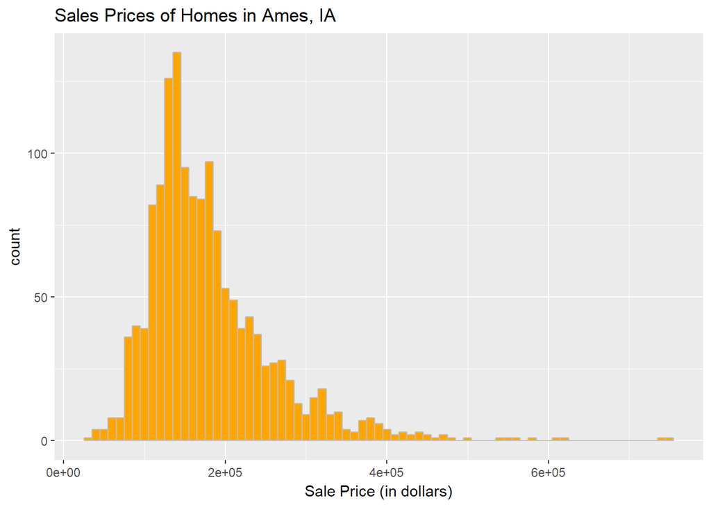

```r
ggplot( homedf, aes(x = SalePrice)) +
  geom_histogram(binwidth=10000, fill = "orange", color = "grey") +
  labs(x = "Sale Price (in dollars)") +
  ggtitle("Sales Prices of Homes in Ames, IA")
```

How expensive are houses?

```r
min(homedf$SalePrice, na.rm = T)
```

```
## [1] 34900
```

```r
max(homedf$SalePrice, na.rm = T)
```

```
## [1] 755000
```

```r
summary(homedf$SalePrice)
```

```
##    Min. 1st Qu.  Median    Mean 3rd Qu.    Max.
##   34900  129975  163000  180921  214000  755000
```

When were the houses built?

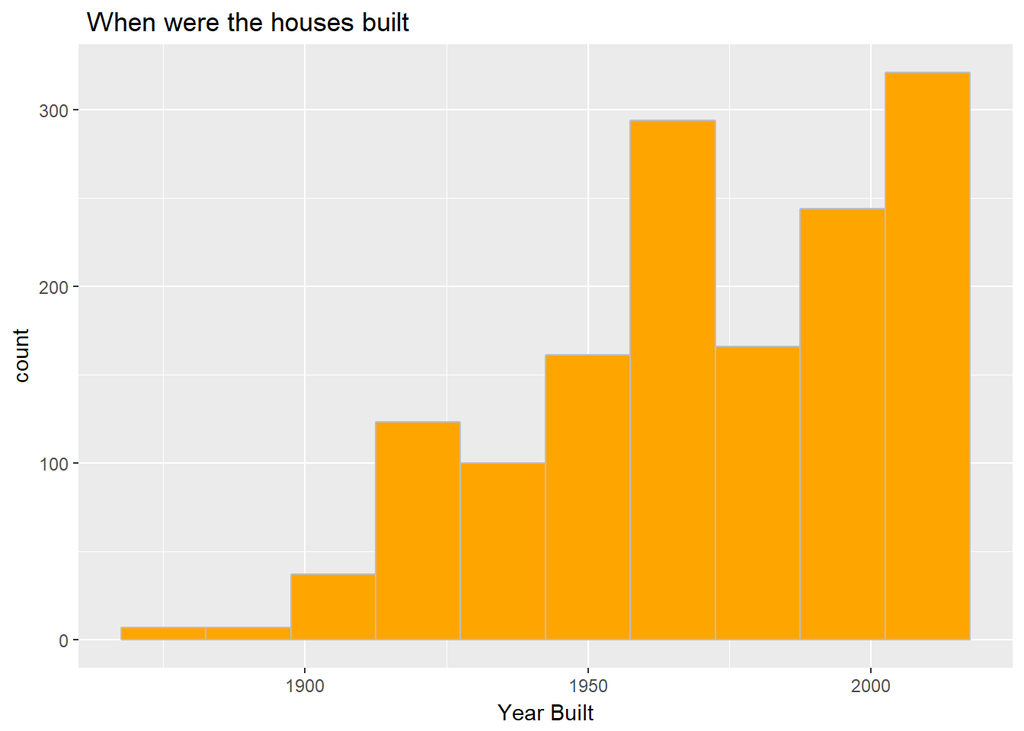

```r
ggplot(homedf, aes(x = YearBuilt)) +
  geom_histogram( binwidth = 15,fill = "orange",color = "grey" ) +
  labs(x = "Year Built") +
   ggtitle(" When were the houses built ")
```

```r
summary(homedf$YearBuilt)
```

```
##    Min. 1st Qu.  Median    Mean 3rd Qu.    Max.
##    1872    1954    1973    1971    2000    2010
```

```r
homedf %>% count(YrSold)
```

```
## # A tibble: 5 x 2
##   YrSold     n
##    <int> <int>
## 1   2006   314
## 2   2007   329
## 3   2008   304
## 4   2009   338
## 5   2010   175
```

Seasonal pattern of homesales

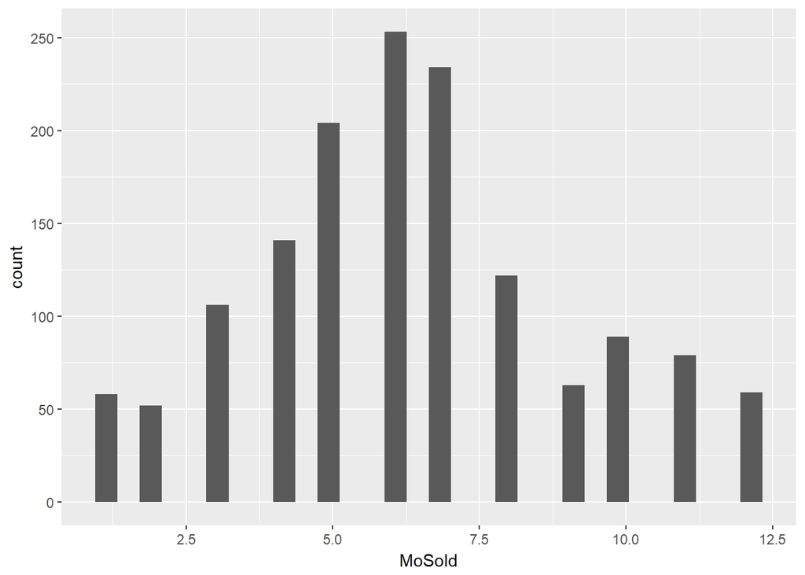

```r
ggplot(homedf, aes(x=MoSold,fill=YrSold))+
  geom_histogram()
```

```r
summary(homedf$MoSold)
```

```
##    Min. 1st Qu.  Median    Mean 3rd Qu.    Max.
##   1.000   5.000   6.000   6.322   8.000  12.000
```

```r
#homedf.groupby(['YrSold','MoSold']).Id.count().plot(kind='bar', figsize=(14,4))
#plt.title('When where houses sold?')
#plt.show()
#ggplot(homedf, aes(YrSold, MoSold))+
 # geom_bar(stat = 'identity',fill = "orange" ,color = "grey",position = "dodge")+
  #ggtitle("Seasonal pattern of Sales")
```

Which neighborhood are houses in?

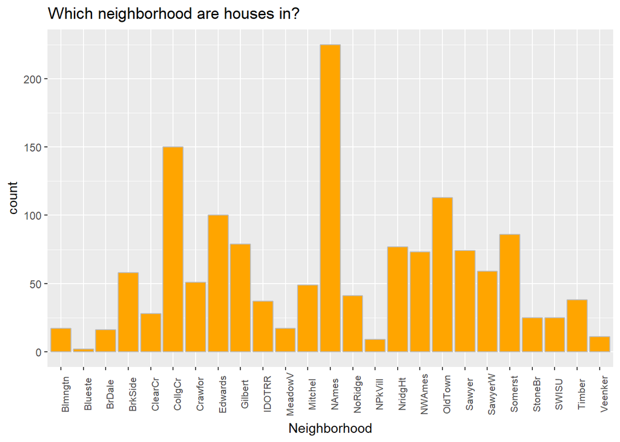

```r
ggplot(homedf, aes(Neighborhood))+
  geom_histogram( stat= 'count',binwidth=14, fill = "orange", color = "grey") +
   theme(axis.text.x = element_text(angle = 90, size = 8), legend.position = "none")+
    ggtitle("Which neighborhood are houses in?")
```

Boxplot of neighborhood and saleprice

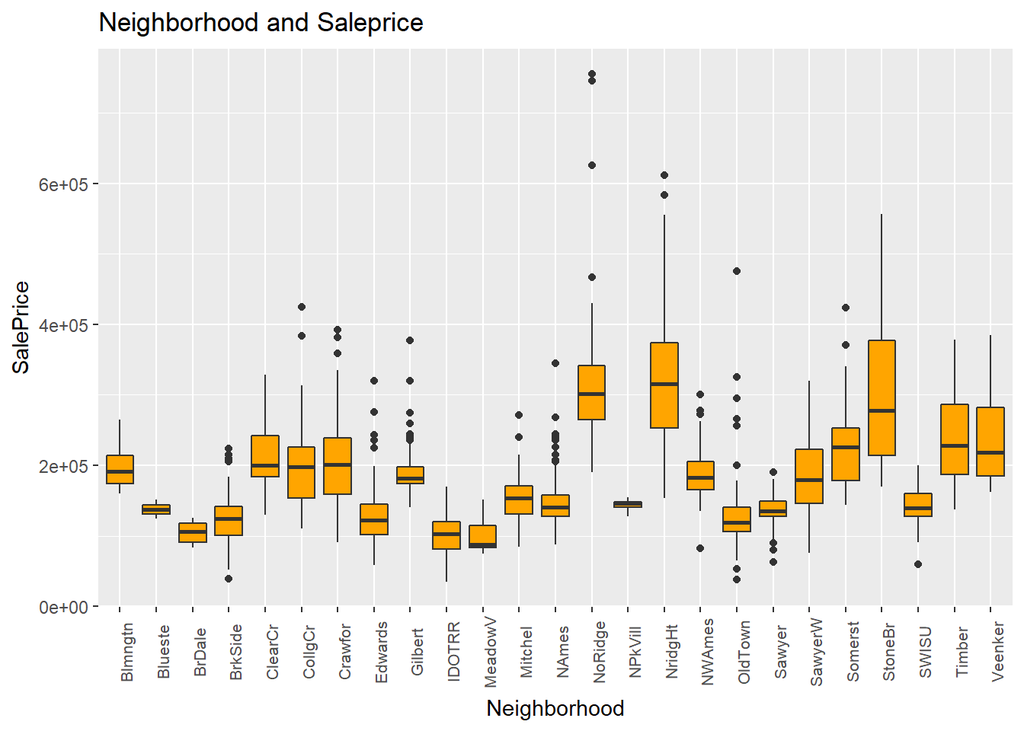

```r
ggplot(homedf, aes(x = Neighborhood, y = SalePrice)) +
  geom_boxplot(fill = "orange") +
  theme(axis.text.x = element_text(angle = 90, size = 8), legend.position = "none") +
  ggtitle("Neighborhood and Saleprice")
```

How big are houses

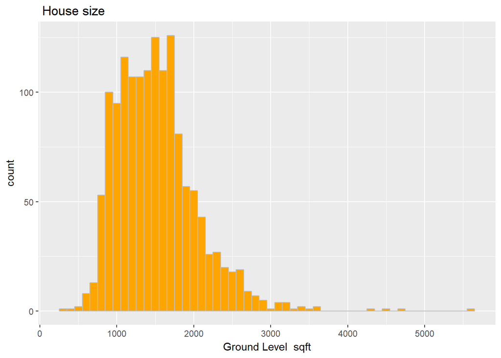

```r
ggplot(homedf, aes(x = GrLivArea)) +
  geom_histogram(binwidth = 100, fill = "orange",color = "grey" ) +
  labs(x = "Ground Level  sqft") +
  ggtitle(" House size ")
```

```r
summary(homedf$GrLivArea)
```

```
##    Min. 1st Qu.  Median    Mean 3rd Qu.    Max.
##     334    1130    1464    1515    1777    5642
```

How big are lots?

```r
summary(homedf$LotArea)
```

```
##    Min. 1st Qu.  Median    Mean 3rd Qu.    Max.
##    1300    7554    9478   10517   11602  215245
```

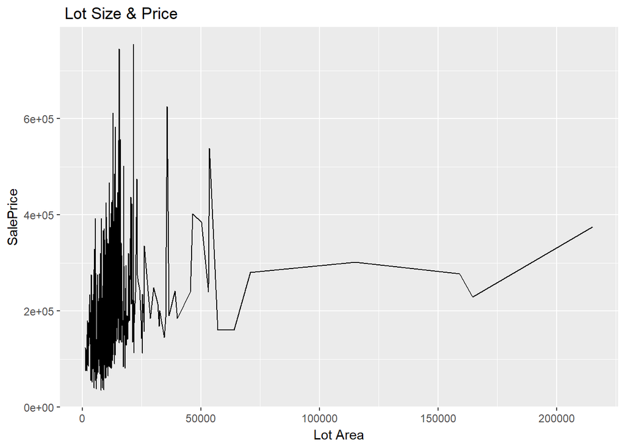

```r
ggplot(homedf, aes(x = LotArea, y = SalePrice )) +
  geom_line() +
  labs(x = "Lot Area") +
  ggtitle(" Lot Size & Price ")
```